# Practical: fitting GLMs to data of multiple species

Physalia workshop on GLLVMs

Bert van der Veen

# Background

The data that is collected in community ecology is almost always non-normal, and very often discrete, which makes GLMs a good fit (much better than LMs). When fitting GLMs, there are many decisions that you need to make before it comes to the actual fitting: a suitable response distribution, formulation of the model, and such. In the first part of this practical, we will fit GLMs, and in the second part vector GLMs.

In the first lecture, we learned about the basics of fitting models to multispecies data. The models so far included basic Generalised Linear Models (GLM), as well as Vector Generalised Linear Models (VGLM). The main difference between the models is one critical assumption. Both can be fitted to multispecies data, but which do we choose? In a GLM, we assume that 1) The response distribution is in the exponential family, 2) We have selected the correct link function, 3) We have selected the correct variance function, 4) There are no outliers that have a large influence on the model, 5) The model is linear on the link scale, 6) Independence of observations, 7) The dispersion parameter is the same for all observations. VGLMs relax assumption 7), which is often much more realistic, but there are distributions where GLMs and VGLMs are the same; namely for the so-called single-parameter exponential distributions. Later today we will consider how we can check if these assumptions are violated. For now, we just focus on understanding and fitting the models.

The exponential family likelihood looks like:

$$\begin{equation}
\mathcal{L}(\Theta) = \prod \limits^m \limits
\prod^n\exp\{\frac{y_{ij}-b(\eta_{ij})}{a(\phi)} + c(y_{ij}, \phi)\}
\end{equation}$$

In the single-parameter exponential family, $a(\phi) = 1$, and the last term $c(y_{ij}, \phi) = c(y_{ij})$ only depends on the data. The dispersion parameter accommodates excess variation that cannot be explained by the model; as with $\sigma^2$ in the normal distribution or linear regression.

We have also discussed the model structure; how we can have effects that are the same for all species, and effects that are species-specific. This is a similar idea as with the dispersion parameter, but for the model on $\eta_{ij}$. That has ecological implications; it speaks to the process we believe the data to be generated from. Estimating effects that are common for all species is easier, because we can leverage from all information in our dataset. For species-specific effects, we only have the information from a particular species. That’s why the latter tend to be more difficult to accurately estimate, and more uncertain.

# Data

The github repository has a “data” folder. You can pick any of the datasets:

1. Beetles (abundance)
2. Birds (abundance)
3. wadden (abundance)
4. wadden (biomass)
5. fungi (presence-absence)
6. eucalypt (presence-absence)

Note, as a rule-of-thumb, discrete data has less information than continuous data, with binary data having the least information, so we need more of it than (say) count data, to accurately estimate parameters.

The packages installed for the workshop also includes datasets, for example the `vegan`, `mvabund` or `gllvm` packages, which you can explore via `data(package="...")`. The `mvabund` package has:

1. “tasmania”: abundances of Copepod and Nematode species in a blocked design under a disturbance treatment
2. “antTraits”: abundance of 41 ant species, with environmental data
3. “solberg”: abundance of benthic invertebrate species with a variable of organic enrichment
4. “spider”: abundance of 12 wolf spider species with environmental variables
5. “tikus”: abundance of coral species over time

and, for example, “dune”, “pyrifos”, “mite”, and “BCI” in the `vegan` R-package.

My suggestion is to try a few different data types in this exercise (e.g., presence-absence (alpine, eucalypt), ordinal (dune, Skabbholmen), abundance (take your pick), biomass (wadden) to get an impression of what it takes to analyse such datatypes. For some of these response types (e.g., ordinal, biomass) it might be more difficult to find software for multispecies modeling that also supports a suitable response distribution, for example, the `glm` function does not include functionality for Tweedie or ordinal responses; we need external packages (but don’t worry, `gllvm` has it all).

# Exploration

Start by choosing a dataset, I will take the waddensea (abundance - it also has biomass) data.

```r
Y <- read.table("../../data/waddenY.csv", sep="," ,header=TRUE, row.names = 2)[,-1]
X <- read.table("../../data/waddenX.csv", sep=",", header=TRUE, row.names = 2)[,-1]
```

This data has 58 macrozoobenthos species and 162 sites sampled on transects at various islands in the German north sea. So there is a repeated design here, indicated by “transect”, “station”, “island” and perhaps “season” columns in the data. There are also a few environmental variables: “elevation”, “TOC”, “DIN”, “RDP”, “Chl.a”, and “silt_clay”. More information on these is available in the associated article by [Dewenter et al. (2023)](https://onlinelibrary.wiley.com/doi/full/10.1002/ece3.10815).

It is good practice to first visualize the data. For example, to make sure there are no outliers, errors, or other abnormalities. `mvabund` can help with our first steps for that:

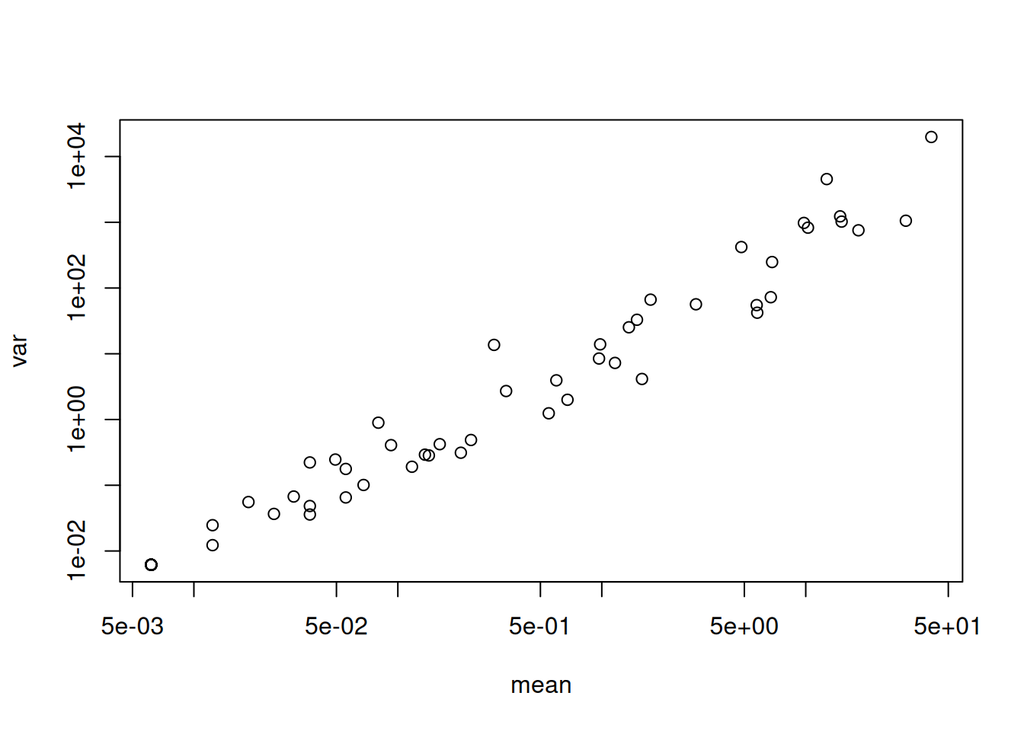

```r
library(mvabund)
require(graphics)
meanvar.plot(mvabund(Y), xlab = "mean", ylab="var")
```

this function plots the variance of each species against its mean. That gives us an impression of the model that we might want to fit. Clearly, the variance increases with the mean. It applies a log transformation to the axes so that the mean-variance relationship is easier to discern, which is appropriate for abundance data. To see how the function creates the plot, we can also do it ourselves:

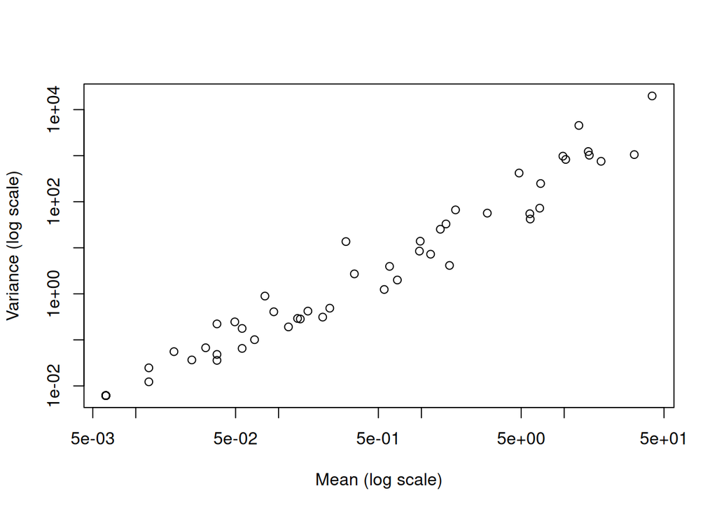

```r
plot(apply(Y,2,var)~colMeans(Y),log="xy", ylab = "Variance (log scale)", xlab="Mean (log scale)")
```

we see that the log of the (sample) variance is linearly related to the log of the (sample) mean. Thus the following equation holds:

$$\begin{equation}
\log{var(y_{ij}) = \alpha\log(\mu_{ij}) + c},
\end{equation}$$

for some constant $c$ (the intercept of the line) and coefficient $\alpha$, the slope of the line. This kind of mean-variance relationship is very common in ecological data. It indicates a power-law relationship, where we “just” need to figure out what the value of $\alpha$ is to determine a suitable response distribution.

For a Poisson distribution, we have $c = 1$ and $\alpha = 1$, so that the variance and mean are the same. For a negative-binomial distribution (2), we have $var(y_{ij}) = \mu_{ij} + \mu_{ij}^2/\theta$, so the line would have to follow the relationship for $\alpha = 2$ and $c = \mu_{ij}$. We can try this by fitting a linear regression:

```r
lm(log(apply(Y,2,var))~log(colMeans(Y)))
```

```
##
## Call:
## lm(formula = log(apply(Y, 2, var)) ~ log(colMeans(Y)))
##
## Coefficients:
##      (Intercept)  log(colMeans(Y))
##            2.481             1.525
```

which, with a slope coefficient of 1.5, is pretty close! You do not always have to go through this process, usually we have a pretty good idea which response distribution is suitable for our data, but it can make for a good sanity check. Before we start modeling, we may also want to plot the response data against the covariates, to see if we can already identify some relationships in advance.

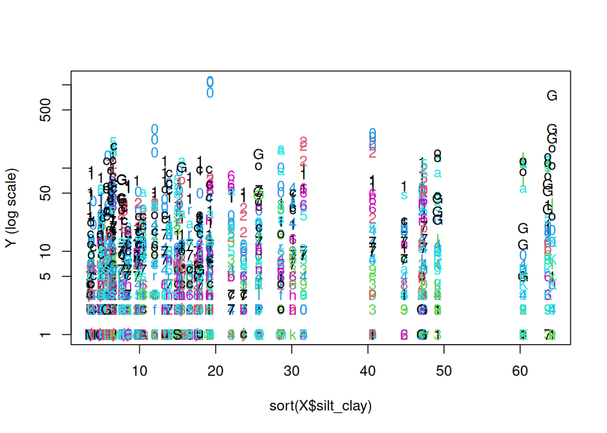

```r
matplot(sort(X$silt_clay),pmax(Y[order(X$silt_clay),], 1), type  ="p", log = "y", ylab = "Y (log scale)")
```

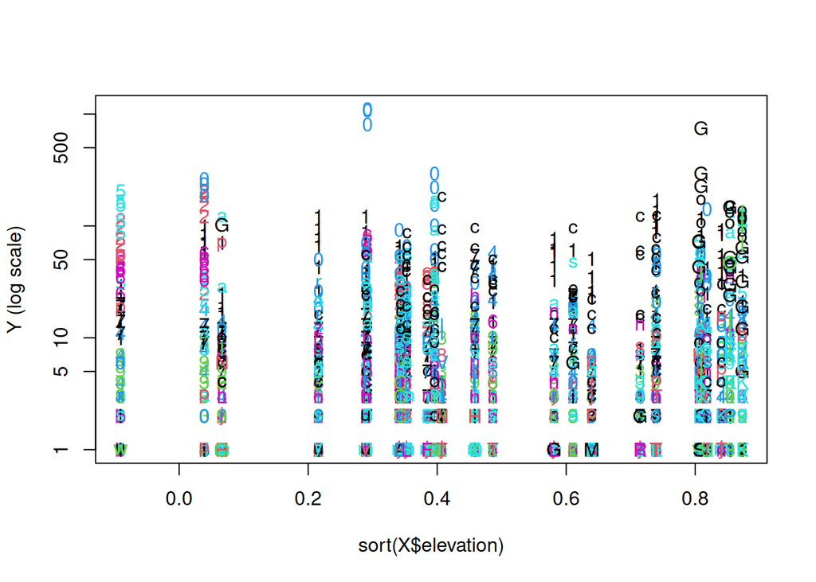

```r
matplot(sort(X$elevation),pmax(Y[order(X$elevation),], 1), type  ="p", log = "y", ylab = "Y (log scale)")
```

That mostly just looks very messy. Not sure we can learn something from these, except that we do not have a lot of samples over the covariates.

# Part I

Let’s just continue to fitting a model. We first need to form the data from wide to long:

```r
data <- data.frame(Y, X)
datalong <- reshape(data,
                    varying = colnames(Y),
                    v.names = "count",
                    idvar = "Site",
                    timevar = "Species",
                    direction = "long")

datalong$Species <- factor(datalong$Species,
                           labels = colnames(Y))
```

```r
model1 <- glm(count~silt_clay + elevation, data = datalong, family = "poisson")
```

Looking at the results:

```r
summary(model1)
```

```
##
## Call:
## glm(formula = count ~ silt_clay + elevation, family = "poisson",
##     data = datalong)
##
## Coefficients:
##               Estimate Std. Error z value Pr(>|z|)
## (Intercept)  1.0142661  0.0115395   87.89   <2e-16 ***
## silt_clay    0.0245632  0.0002919   84.15   <2e-16 ***
## elevation   -0.6528611  0.0190549  -34.26   <2e-16 ***
## ---
## Signif. codes:  0 '***' 0.001 '**' 0.01 '*' 0.05 '.' 0.1 ' ' 1
##
## (Dispersion parameter for poisson family taken to be 1)
##
##     Null deviance: 184211  on 9395  degrees of freedom
## Residual deviance: 177306  on 9393  degrees of freedom
## AIC: 183876
##
## Number of Fisher Scoring iterations: 8
```

we see loads of significance! Yay! Or, is that good? Statistical significance is mostly a function of information; the more information we have, the more significant a result will be. Here, because we assumed the effects to be the same for all species, there is loads of information to estimate them. So, the statistical significance is probably of minor relevance. We also see that the effects are pretty close to zero, but that may not be meaningful as we have not standardised our covariates. Let’s try that again:

```r
model2 <- glm(count~scale(silt_clay) + scale(elevation), data = datalong, family = "poisson")
summary(model2)
```

```
##
## Call:
## glm(formula = count ~ scale(silt_clay) + scale(elevation), family = "poisson",
##     data = datalong)
##
## Coefficients:
##                   Estimate Std. Error z value Pr(>|z|)
## (Intercept)       1.134280   0.006068  186.93   <2e-16 ***
## scale(silt_clay)  0.400437   0.004758   84.15   <2e-16 ***
## scale(elevation) -0.174275   0.005087  -34.26   <2e-16 ***
## ---
## Signif. codes:  0 '***' 0.001 '**' 0.01 '*' 0.05 '.' 0.1 ' ' 1
##
## (Dispersion parameter for poisson family taken to be 1)
##
##     Null deviance: 184211  on 9395  degrees of freedom
## Residual deviance: 177306  on 9393  degrees of freedom
## AIC: 183876
##
## Number of Fisher Scoring iterations: 8
```

The benefit of centering and standardising the covariates, is that we can compare the magnitude of the coefficients for different covariates. Now, a coefficient further from zero means there is a stronger effect on the response variable. You may think that we changed the model, but we have not, we have just reparameterized it. We can check this by extracting the log-likelihood of the two models, so that we see they are the same:

```r
logLik(model1)
```

```
## 'log Lik.' -91935.02 (df=3)
```

```r
logLik(model2)
```

```
## 'log Lik.' -91935.02 (df=3)
```

We can also prove it mathematically:

$$\begin{equation}
\begin{aligned}
y_{ij} &= \alpha + siltclay_i\beta_1 + elevation_i \beta_2\\
&= \alpha + \frac{(siltclay_i-\mu_1)}{\sigma_1}\beta_1 +
\frac{(elevation_i-\mu_2)}{\sigma_2}\beta_2\\
&= \alpha -\mu_1\beta_1/\sigma_1 -\mu_2\beta_2/\sigma_2 +
siltclay_i\beta_1/\sigma_1 + elevation_i\beta_2/\sigma_2\\
&= \alpha^* + siltclay_i\beta_1^* + elevation_i \beta_2^*
\end{aligned}
\end{equation}$$

so that $alpha^*$, $\beta_1^*$ and $\beta_2^*$ are the coefficients from the second model. Scaling and centering covariates is important to compare effects, but for more complex models (including random effects, for example), it is also crucial for *convergence*.

Anyway, let’s continue by plotting the coefficients with their confidence intervals:

```r
par(mar=c(5,7,4,2))
CIs <- confint(model2)
```

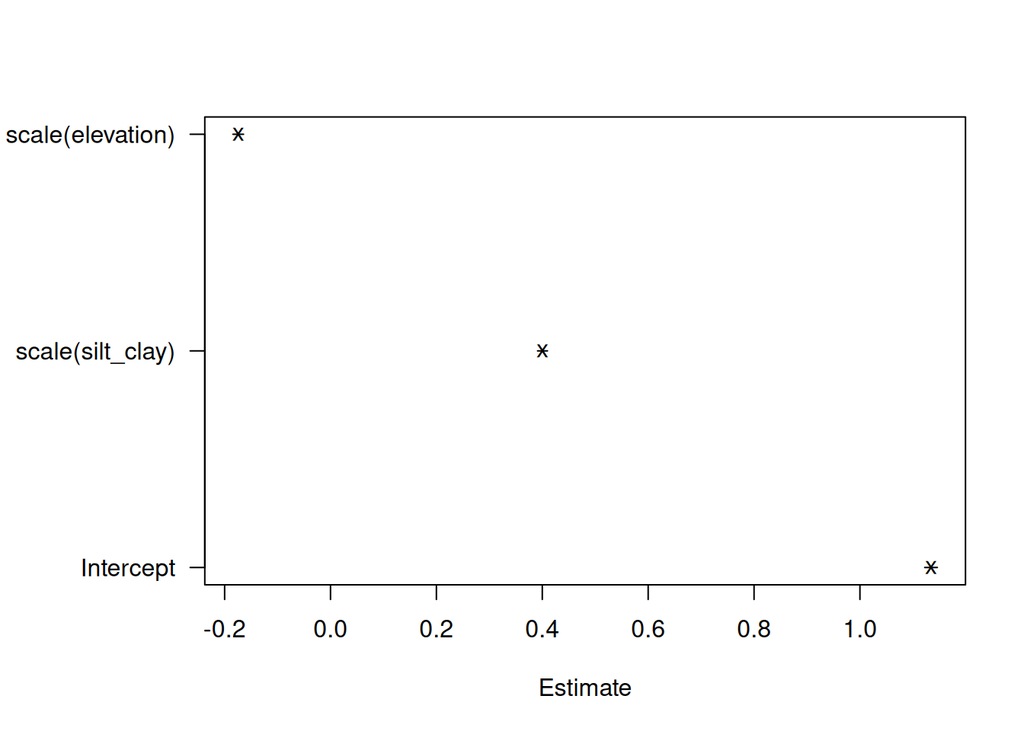

```r
est <-  coef(model2)
plot(x = est, y = 1:length(est), xlab = "Estimate", ylab = NA, pch  = "x", xlim = range(CIs), yaxt = "n")
axis(2, 1:length(est), c("Intercept", labels(terms(model2))), las = 1)
segments(CIs[,"2.5 %"], 1:length(est), CIs[,"97.5 %"], 1:length(est))
```

Excellent, this makes things much easier to interpret. So, on average over all species, elevation is estimated to have a negative effect, and silt_clay a positive effect. We have assumed these to be the same for all species, the intercept too. This makes for a nice and small, easy to interpret model, but it is not ecologically realistic. In the next models, we will incorporate the species identities too. I did not clarify this in the presentation, but you may have heard once upon a time “do not include higher order terms without lower order terms”; the general advice when fitting a statistical model. This is a good place to operate from, but we will ignore it anyway (and it is OK to do so).

```r
model3 <- glm(count~ 0 + Species + scale(silt_clay):Species + scale(elevation):Species, data = datalong, family = "poisson")
```

```
## Warning: glm.fit: fitted rates numerically 0 occurred
```

The `0+` serves to ensure that the estimates are not all relative to the first species (we absorb the global intercept term into the other terms).

This model throws a warning, do you understand why? I will tell you: we did not screen the data for species with few observations. Now, we are fitting a model with 3 parameters per species: the intercept, and two slope parameters (one for silt_clay and another for elevation). That means we need at least 3 (non-zero) observations to be able to (inaccurately) estimate the parameters. Let’s check how many we have:

```r
table(colSums(ifelse(Y==0,0,1)))
```

```
##
##   1   2   3   5   6   8   9  14  15  16  18  20  23  24  25  30  36  39  42  45
##  15   4   3   2   1   1   1   2   1   2   1   3   2   1   1   1   1   1   1   1
##  46  57  63  80  84  91  93 119 122 123 136 140 151
##   1   1   1   1   1   1   1   1   1   1   1   1   1
```

Let’s formulate another model, this time with the main terms:

```r
model4 <- glm(count~Species + scale(silt_clay) + scale(elevation) + scale(silt_clay):Species + scale(elevation):Species, data = datalong, family = "poisson")
```

again, we can show that these models are equivalent. They have the same number of parameters, and they thus have the same log likelihood value:

```r
logLik(model3)
```

```
## 'log Lik.' -35500.51 (df=174)
```

```r
logLik(model4)
```

```
## 'log Lik.' -35500.51 (df=174)
```

but, the former parameterisation is much more intuitive than the latter, so let’s plot the coefficients for that. The standard `confint` might take too long for these models; it does likelihood profiling which involves refitting models many times. Calculating the confidence intervals based on the assumption of asymptotic normality will only take a second, so we’ll do that here instead.

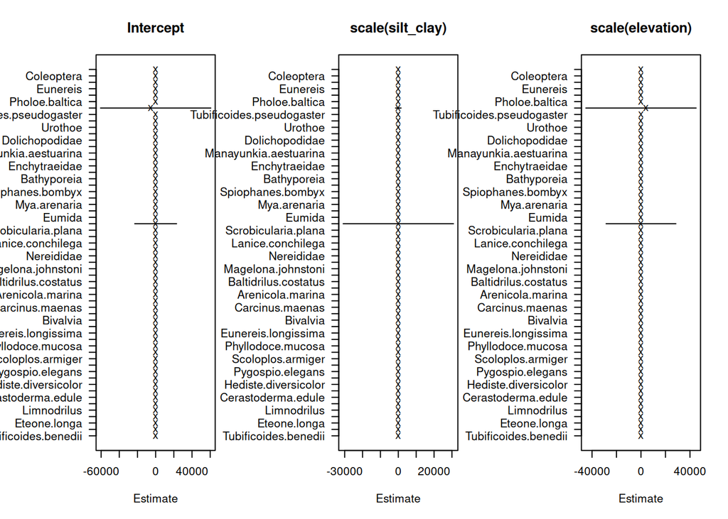

```r
par(mar=c(5,7,4,2), mfrow = c(1, 3))
ses <- matrix(sqrt(diag(vcov(model3))), ncol = 3)
LI <- est + qnorm(1-0.975)*ses
UI <- est + qnorm(0.975)*ses
est <- matrix(coef(model3), ncol = 3)
for(i in 1:3){
plot(x = est[,i], y = 1:nrow(est), xlab = "Estimate", ylab = NA, pch  = "x", xlim = c(min(LI[,i]), max(UI[,i])), yaxt = "n", main = c("Intercept",  labels(terms(model2)))[i])
axis(2, 1:nrow(est), colnames(Y), las = 1)
segments(LI[,i], 1:nrow(est), UI[,i], 1:nrow(est))
}
```

You can probably identify the species that have too little data from these plots.

## Tasks

The goal of this first part is to get familiar with the ideas of multispecies modeling. Here is what I want you to do:

1. Explore the models displayed above. Either for the used dataset, or any of the other listed datasets. Fit them in your own R session and explore the results. You can also select different covariates.
2. Consider doing model selection, with `AIC` or with `anova`, for example. Can you figure out what drives this community?
3. If you want to do something really daring, try changing the contrast for the ‘Species’ covariate to a sum-to-zero contrast (and isolate the species-common effect)
4. After a while we will discuss together how far you got, questions or challenges that have come up, and what conclusions you were able to draw.

# Part II

In this second part, we will look at vector GLMs. The equation for the likelihood from before becomes:

$$\begin{equation}
\mathcal{L}(\Theta) = \prod \limits^m \limits
\prod^n\exp\{\frac{y_{ij}-b(\eta_{ij})}{a(\phi)} + c(y_{ij}, \phi)\}
\end{equation}$$

where the difference between a VGLM and GLM is that the dispersion parameter $\phi = \phi_j$, so that it is not the same for all observations, but instead each species gets its own dispersion parameter. It may seem like a trivial extension, which it is if we have only species-specific parameters in the model. Then, it means we are “just” fitting a GLM to the data of every species. Let’s verify this:

```r
GLMs <- list()
for(j in 1:ncol(Y)){
  GLMs[[j]] <- glm(Y[,j]~silt_clay + elevation, family = "poisson", data = X)
}
Reduce("+", lapply(GLMs, logLik))
```

```
## 'log Lik.' -35500.51 (df=3)
```

which just sums the likelihoods of all the separate models, which is the same as the model we just fitted above. We can also fit in with just a single line of code using the `gllvm` package:

```r
X <- X[,-which(apply(X,2, anyNA))] # remove column with NAs
library(gllvm)
model5 <- gllvm(Y, X, formula = ~silt_clay + elevation, family = "poisson", num.lv = 0)
logLik(model5)
```

```
## 'log Lik.' -35500.69 (df=174)
```

```r
summary(model5, digits = 3L)
```

```
##
## Call:
## gllvm(y = Y, X = X, formula = ~silt_clay + elevation, family = "poisson",
##     num.lv = 0)
##
## Family:  poisson
##
## AIC:  71349.37 AICc:  71355.98 BIC:  72593.13 LL:  -35501 df:  174
##
## Informed LVs:  0
## Constrained LVs:  0
## Unconstrained LVs:  0
##
## Formula:  ~silt_clay + elevation
## LV formula:  ~1
## Row effect:  ~ 1
##
## Coefficients predictors:
##                                      Estimate Std. Error   z value Pr(>|z|)
## silt_clay:Tubificoides.benedii      -1.63e-03   9.10e-04 -1.79e+00  0.07347 .
## silt_clay:Aphelochaeta.marioni       1.77e-02   1.36e-03  1.30e+01  < 2e-16 ***
## silt_clay:Eteone.longa              -2.10e-03   2.05e-03 -1.02e+00  0.30659
## silt_clay:Limecola.balthica          1.38e-02   1.63e-03  8.43e+00  < 2e-16 ***
## silt_clay:Limnodrilus                2.25e-02   1.48e-03  1.52e+01  < 2e-16 ***
## silt_clay:Heteromastus.filiformis    2.22e-02   1.94e-03  1.14e+01  < 2e-16 ***
## silt_clay:Cerastoderma.edule         1.70e-03   2.26e-03  7.50e-01  0.45113
## silt_clay:Urothoe.poseidonis        -8.54e-02   1.32e-02 -6.47e+00  9.8e-11 ***
## silt_clay:Hediste.diversicolor       2.21e-02   3.47e-03  6.37e+00  1.9e-10 ***
## silt_clay:Peringia.ulvae             1.16e-02   7.57e-04  1.53e+01  < 2e-16 ***
## silt_clay:Pygospio.elegans           3.96e-02   1.01e-03  3.92e+01  < 2e-16 ***
## silt_clay:Alitta.succinea            2.03e-02   1.34e-02  1.51e+00  0.13103
## silt_clay:Scoloplos.armiger         -4.01e-02   1.93e-03 -2.07e+01  < 2e-16 ***
## silt_clay:Crangon.crangon           -5.98e-02   2.95e-02 -2.03e+00  0.04260 *
## silt_clay:Phyllodoce.mucosa          1.50e-02   1.33e-02  1.13e+00  0.25821
## silt_clay:Retusa.obtusa             -1.70e-02   8.97e-03 -1.90e+00  0.05764 .
## silt_clay:Eunereis.longissima        1.56e-02   5.09e-03  3.06e+00  0.00221 **
## silt_clay:Corophium.arenarium       -1.92e-02   5.91e-03 -3.25e+00  0.00116 **
## silt_clay:Bivalvia                  -8.90e-03   9.90e-03 -9.00e-01  0.36838
## silt_clay:Bathyporeia.sarsi         -1.59e-01   5.58e-02 -2.86e+00  0.00425 **
## silt_clay:Carcinus.maenas            3.49e-02   8.01e-03  4.36e+00  1.3e-05 ***
```

[output cut: 82 more lines]

```
## elevation:Polydora.cornuta           5.74e+00   5.68e-01  1.01e+01  < 2e-16 ***
## elevation:Dolichopodidae             1.11e+01   2.20e+00  5.04e+00  4.7e-07 ***
## elevation:Grania                    -4.24e+00   1.89e+00 -2.25e+00  0.02476 *
## elevation:Urothoe                   -9.38e+00   4.50e-02 -2.09e+02  < 2e-16 ***
## elevation:Aphelochaeta              -5.69e+00   1.58e+00 -3.60e+00  0.00032 ***
## elevation:Tubificoides.pseudogaster  2.87e+01   1.03e-01  2.80e+02  < 2e-16 ***
## elevation:Monopylephorus.irroratus   6.22e+03   1.89e+00  3.28e+03  < 2e-16 ***
## elevation:Pholoe.baltica            -6.36e-01   6.37e-01 -1.00e+00  0.31769
## elevation:Bathyporeia.elegans        4.25e+00   9.26e-01  4.59e+00  4.5e-06 ***
## elevation:Eunereis                   7.99e+00   6.15e-01  1.30e+01  < 2e-16 ***
## elevation:Corophium                  3.17e+00   2.40e+00  1.32e+00  0.18704
## elevation:Coleoptera                 2.52e+01   9.90e-01  2.54e+01  < 2e-16 ***
## elevation:Urothoe.pulchella         -2.74e+00   1.52e+00 -1.80e+00  0.07210 .
## ---
## Signif. codes:  0 '***' 0.001 '**' 0.01 '*' 0.05 '.' 0.1 ' ' 1
```

OK, it is not **exactly** the same as before, but pretty close. That is because the `gllvm` package uses numerical optimisation, while the `glm` function in R uses a smart algorithm called iteratively re-weighted least squares. That is harder to use with random effects, and that is what `gllvm` is meant to do (so no IRWLS).

```r
summary(model6)
```

[output not shown]

```
##
## Call:
## gllvm(y = Y, family = "poisson", num.lv = 0, studyDesign = X,
##     row.eff = ~scale(silt_clay) + scale(elevation))
##
## Family:  poisson
##
## AIC:  93359.47 AICc:  93360.25 BIC:  93788.35 LL:  -46620 df:  60
##
## Informed LVs:  0
## Constrained LVs:  0
## Unconstrained LVs:  0
##
## Formula:  ~ 1
## LV formula:  ~ 0
## Row effect:  ~scale(silt_clay) + scale(elevation)
##
## Coefficients predictors:
##                   Estimate Std. Error z value Pr(>|z|)
## scale(silt_clay)  0.401657   0.004773   84.15   <2e-16 ***
## scale(elevation) -0.174806   0.005102  -34.26   <2e-16 ***
## ---
## Signif. codes:  0 '***' 0.001 '**' 0.01 '*' 0.05 '.' 0.1 ' ' 1
```

The Poisson distribution is in the single-parameter exponential family, so we could continue with the `glm` function if we wanted to and the results would be the same. However, we are here to work with `gllvm` so let’s use that instead! That way, you can get familiar with its functionality before we move on to more complex models.

You already know how to create caterpillar plots (the name for the plots we made before) but now we have a function to do it for us:

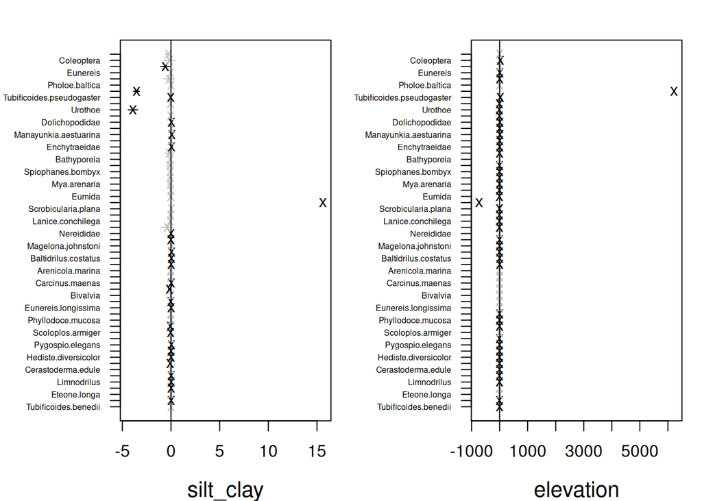

```r
coefplot(model5, order = FALSE)
```

if the confidence interval crosses zero, the species’ effect is greyed out as it is too uncertain to draw any conclusions. The confidence intervals are again drawn assuming asymptotic normality.

Compared to the models we have fitted before, the models in `gllvm` correspond to “dummy coding”, so that there is no “common” effect, but species-specific effects instead, as long as things are treated as fixed. In this framework, we can now straightforwardly move to a distribution outside of the single-parameter exponential family; so we can fit (for example) a negative-binomial model that accommodates overdispersion per species.

I will not show equivalence with separate negative-binomial GLMs fitted to the data of each species, because the software for fitting negative-binomial GLMs (e.g., as in the `MASS` R-package) is not sufficiently robust; issues arise.

Similar functionality applies here: we can apply `anova` or `aic` for model comparison, we can use `confint` to get the confidence intervals, `coef` for the coefficients (estimates), `summary` to get some useful information on the model, and `coefplot` we already used before.

From here, we could choose to explore the biomass equivalent of the same data (“WaddenY2”), with a Tweedie distribution. Without going into too much detail, the Tweedie family is a class of distributions, including the Poisson distribution, for positive continuous data with zeros (such as biomass). It has a dispersion parameter and a Power parameter. The variance function looks like:

$$\begin{equation}
\begin{aligned}
\text{var}(\textbf{y}_j) &= \phi_j\mu^p\\
\log\{\text{var}(\textbf{y}_j)\} &= \log{\phi_j} + p\log{\mu},
\end{aligned}
\end{equation}$$

where $p$ is the power parameter and $\phi$ is the dispersion parameter as before. Note, this looks very similar to the variance function written above! The Power parameter controls the exact distribution that you have, and can be estimated by the package, so that it provides for very flexible modeling of biomass.

## Tasks

Try fitting a few models with the `gllvm` package; it’s why you are here after all! Each data type has its own “quirks” (ordinal classes are different from cover, which is different from biomass, and so on), and it is best to understand these before getting into more complex models. The data directory on the github has most types, so go through some modeling with different data types at this point.

1. Biomass data (e.g., the waddensea data)
2. Cover data (e.g., the road data)
3. Cover classes (e.g., the Skabbholmen data in `gllvm` or the dune data in `vegan`)
4. Binary data (e.g., the SwissBirds data)
5. Count data (e.g., the beetles data)

In terms of tasks, you can go through similar steps as you did in the first part of the exercise: explore the data, fit some models, do some model selection, and see if you can draw ecological conclusions using the information at your disposal (parameter estimates and statistical uncertainty).